# R 語言特訓班 3：資料轉換與整合

黃大維，臺灣大學統計碩士

2018年5月1日

## 3-1：dplyr 套件與資料轉換

在進行資料分析時，我們通常需要先構思以下三件事情：

- 我們可能要使用的分析方法是什麼？
- 我們需要怎麼樣的 input data 才能進行分析？
- 我們需要怎麼樣的 output data 才能視覺化分析結果？

`dplyr`是 R 語言中最常被用來進行資料轉換的套件，內建許多與 SQL 相似的函數，幫助我們在 R 中完成資料轉換。`dplyr` 套件有幾個好處：

- 提供以「動詞」為命名的函數，讓你能夠直接將想達成的資料轉換翻譯成程式碼
- 提供資料轉換的「標準化框架」，有系統的思考你需要做的資料轉換
- 在效能上有優化，較其他套件的函數快上不少

```r
library(tidyverse)
# library(dplyr)
```

## 3-2：資料篩選與排序

當手上的資料集合非常龐大時，在整個資料集合上做整理、轉換、分析、建模、甚至是繪圖的效率都會大幅降低。因此，進行資料轉換的第一步應該是「篩選出我們真正需要的資料」，而非直接拿整個資料集合去做運算。`dplyr` 套件提供了兩個方便進行資料篩選的函數：

- Row 的篩選：`filter` 函數
- Column 的篩選：`select` 函數

### 1. 利用 `filter` 函數篩選出需要的 row

首先，我們先來看看今天使用的範例集合：`mtcars`，裡面有 1973 - 1974 年 32 款汽車的相關變數 11 種。詳細的說明看：https://www.rdocumentation.org/packages/datasets/versions/3.5.0/topics/mtcars 。

```r
mtcars.tb <- as_tibble(mtcars)
print(mtcars.tb)
```

```
## # A tibble: 32 x 11
##      mpg   cyl  disp    hp  drat    wt  qsec    vs    am  gear  carb
##  * <dbl> <dbl> <dbl> <dbl> <dbl> <dbl> <dbl> <dbl> <dbl> <dbl> <dbl>
##  1  21       6  160    110  3.9   2.62  16.5     0     1     4     4
##  2  21       6  160    110  3.9   2.88  17.0     0     1     4     4
##  3  22.8     4  108     93  3.85  2.32  18.6     1     1     4     1
##  4  21.4     6  258    110  3.08  3.22  19.4     1     0     3     1
##  5  18.7     8  360    175  3.15  3.44  17.0     0     0     3     2
##  6  18.1     6  225    105  2.76  3.46  20.2     1     0     3     1
##  7  14.3     8  360    245  3.21  3.57  15.8     0     0     3     4
##  8  24.4     4  147.    62  3.69  3.19  20       1     0     4     2
##  9  22.8     4  141.    95  3.92  3.15  22.9     1     0     4     2
## 10  19.2     6  168.   123  3.92  3.44  18.3     1     0     4     4
## # ... with 22 more rows
```

```r
mtcars.tb %>%
  filter(mpg > 20, hp > 100)
```

```
## # A tibble: 5 x 11
##     mpg   cyl  disp    hp  drat    wt  qsec    vs    am  gear  carb
##   <dbl> <dbl> <dbl> <dbl> <dbl> <dbl> <dbl> <dbl> <dbl> <dbl> <dbl>
## 1  21       6 160     110  3.9   2.62  16.5     0     1     4     4
## 2  21       6 160     110  3.9   2.88  17.0     0     1     4     4
## 3  21.4     6 258     110  3.08  3.22  19.4     1     0     3     1
## 4  30.4     4  95.1   113  3.77  1.51  16.9     1     1     5     2
## 5  21.4     4 121     109  4.11  2.78  18.6     1     1     4     2
```

### 2. 利用 `select` 函數篩選出需要的 column

如果我們只需要看「一加侖汽油可跑距離」、「馬力」、與「前進檔數」三個變數，可以使用 `select` 函數：

```r
mtcars.tb %>%
  select(mpg, hp, gear)
```

```
## # A tibble: 32 x 3
##      mpg    hp  gear
##  * <dbl> <dbl> <dbl>
##  1  21     110     4
##  2  21     110     4
##  3  22.8    93     4
##  4  21.4   110     3
##  5  18.7   175     3
##  6  18.1   105     3
##  7  14.3   245     3
##  8  24.4    62     4
##  9  22.8    95     4
## 10  19.2   123     4
## # ... with 22 more rows
```

```r
mtcars.tb %>%
  filter(
    mpg > 20,
    hp > 100) %>%
  select(gear)
```

```
## # A tibble: 5 x 1
##    gear
##   <dbl>
## 1     4
## 2     4
## 3     3
## 4     5
## 5     4
```

### 3. 利用 `arrange` 函數進行資料排序

假設我們想要根據某一個 columns 將資料集合的 rows 做排序，可以使用 `arrange` 函數，同時也可以按照多個 columns 的順序進行排序，會按照 columns 的先後順序進行排序。原始設定是升冪排列，如果想要改成降冪排列的話可以使用 `desc(column_name)` 指令。

```r
mtcars.tb %>%
  arrange(
    cyl,
    disp
  )
```

```
## # A tibble: 32 x 11
##      mpg   cyl  disp    hp  drat    wt  qsec    vs    am  gear  carb
##    <dbl> <dbl> <dbl> <dbl> <dbl> <dbl> <dbl> <dbl> <dbl> <dbl> <dbl>
##  1  33.9     4  71.1    65  4.22  1.84  19.9     1     1     4     1
##  2  30.4     4  75.7    52  4.93  1.62  18.5     1     1     4     2
##  3  32.4     4  78.7    66  4.08  2.2   19.5     1     1     4     1
##  4  27.3     4  79      66  4.08  1.94  18.9     1     1     4     1
##  5  30.4     4  95.1   113  3.77  1.51  16.9     1     1     5     2
##  6  22.8     4 108      93  3.85  2.32  18.6     1     1     4     1
##  7  21.5     4 120.     97  3.7   2.46  20.0     1     0     3     1
##  8  26       4 120.     91  4.43  2.14  16.7     0     1     5     2
##  9  21.4     4 121     109  4.11  2.78  18.6     1     1     4     2
## 10  22.8     4 141.     95  3.92  3.15  22.9     1     0     4     2
## # ... with 22 more rows
```

```r
mtcars.tb %>%
  arrange(
    desc(disp)
  )
```

```
## # A tibble: 32 x 11
##      mpg   cyl  disp    hp  drat    wt  qsec    vs    am  gear  carb
##    <dbl> <dbl> <dbl> <dbl> <dbl> <dbl> <dbl> <dbl> <dbl> <dbl> <dbl>
##  1  10.4     8   472   205  2.93  5.25  18.0     0     0     3     4
##  2  10.4     8   460   215  3     5.42  17.8     0     0     3     4
##  3  14.7     8   440   230  3.23  5.34  17.4     0     0     3     4
##  4  19.2     8   400   175  3.08  3.84  17.0     0     0     3     2
##  5  18.7     8   360   175  3.15  3.44  17.0     0     0     3     2
##  6  14.3     8   360   245  3.21  3.57  15.8     0     0     3     4
##  7  15.8     8   351   264  4.22  3.17  14.5     0     1     5     4
##  8  13.3     8   350   245  3.73  3.84  15.4     0     0     3     4
##  9  15.5     8   318   150  2.76  3.52  16.9     0     0     3     2
## 10  15.2     8   304   150  3.15  3.44  17.3     0     0     3     2
## # ... with 22 more rows
```

## 3-3：使用 `mutate` 建立新的變數

在傳統 data.frame 的架構下，我們時常使用類似 `data.frame$new_var <- data.frame$old_var1 / data.frame$old_var2`，這樣的程式碼非常不乾淨簡潔，因此在 `tidy` 架構下，我們喜歡使用 `mutate` 函數，將原資料集合的變數做運算與得到新變數。

`mutate` 函數會將新的變數儲存在原資料集合的最後一個 column。

```r
# Newly created variables are available immediately
mtcars.tb %>%
  mutate(
    cyl2 = cyl * 2,
    cyl4 = cyl2 * 2
  )
```

```
## # A tibble: 32 x 13
##      mpg   cyl  disp    hp  drat    wt  qsec    vs    am  gear  carb  cyl2
##    <dbl> <dbl> <dbl> <dbl> <dbl> <dbl> <dbl> <dbl> <dbl> <dbl> <dbl> <dbl>
##  1  21       6  160    110  3.9   2.62  16.5     0     1     4     4    12
##  2  21       6  160    110  3.9   2.88  17.0     0     1     4     4    12
##  3  22.8     4  108     93  3.85  2.32  18.6     1     1     4     1     8
##  4  21.4     6  258    110  3.08  3.22  19.4     1     0     3     1    12
##  5  18.7     8  360    175  3.15  3.44  17.0     0     0     3     2    16
##  6  18.1     6  225    105  2.76  3.46  20.2     1     0     3     1    12
##  7  14.3     8  360    245  3.21  3.57  15.8     0     0     3     4    16
##  8  24.4     4  147.    62  3.69  3.19  20       1     0     4     2     8
##  9  22.8     4  141.    95  3.92  3.15  22.9     1     0     4     2     8
## 10  19.2     6  168.   123  3.92  3.44  18.3     1     0     4     4    12
## # ... with 22 more rows, and 1 more variable: cyl4 <dbl>
```

```r
# You can also use mutate() to remove variables and
# modify existing variables
mtcars.tb %>%
  mutate(
    mpg = NULL,
    disp = disp * 0.0163871 # convert to litres
  )
```

```
## # A tibble: 32 x 10
##      cyl  disp    hp  drat    wt  qsec    vs    am  gear  carb
##    <dbl> <dbl> <dbl> <dbl> <dbl> <dbl> <dbl> <dbl> <dbl> <dbl>
##  1     6  2.62   110  3.9   2.62  16.5     0     1     4     4
##  2     6  2.62   110  3.9   2.88  17.0     0     1     4     4
##  3     4  1.77    93  3.85  2.32  18.6     1     1     4     1
##  4     6  4.23   110  3.08  3.22  19.4     1     0     3     1
##  5     8  5.90   175  3.15  3.44  17.0     0     0     3     2
##  6     6  3.69   105  2.76  3.46  20.2     1     0     3     1
##  7     8  5.90   245  3.21  3.57  15.8     0     0     3     4
##  8     4  2.40    62  3.69  3.19  20       1     0     4     2
##  9     4  2.31    95  3.92  3.15  22.9     1     0     4     2
## 10     6  2.75   123  3.92  3.44  18.3     1     0     4     4
## # ... with 22 more rows
```

如果你只希望保留新建立的變數，可以利用 `transmute` 函數。

```r
mtcars.tb %>%
  transmute(displ_l = disp / 61.0237)
```

```
## # A tibble: 32 x 1
##    displ_l
##      <dbl>
##  1    2.62
##  2    2.62
##  3    1.77
##  4    4.23
##  5    5.90
##  6    3.69
##  7    5.90
##  8    2.40
##  9    2.31
## 10    2.75
## # ... with 22 more rows
```

## 3-4：根據組別加總與統整資料

如果你有學過 SQL，對於 `group_by` 這樣的函數絕對不會陌生。假設我們想針對車子的汽缸數量做分組，可以利用以下指令：

```r
mtcars.tb %>%
  group_by(cyl)
```

```
## # A tibble: 32 x 11
## # Groups:   cyl [3]
##      mpg   cyl  disp    hp  drat    wt  qsec    vs    am  gear  carb
##  * <dbl> <dbl> <dbl> <dbl> <dbl> <dbl> <dbl> <dbl> <dbl> <dbl> <dbl>
##  1  21       6  160    110  3.9   2.62  16.5     0     1     4     4
##  2  21       6  160    110  3.9   2.88  17.0     0     1     4     4
##  3  22.8     4  108     93  3.85  2.32  18.6     1     1     4     1
##  4  21.4     6  258    110  3.08  3.22  19.4     1     0     3     1
##  5  18.7     8  360    175  3.15  3.44  17.0     0     0     3     2
##  6  18.1     6  225    105  2.76  3.46  20.2     1     0     3     1
##  7  14.3     8  360    245  3.21  3.57  15.8     0     0     3     4
##  8  24.4     4  147.    62  3.69  3.19  20       1     0     4     2
##  9  22.8     4  141.    95  3.92  3.15  22.9     1     0     4     2
## 10  19.2     6  168.   123  3.92  3.44  18.3     1     0     4     4
## # ... with 22 more rows
```

看起來好像沒發生什麼特別的事情，但如果我們利用 R 的 debug 函數 `brower()` 去看看 `group_by` 的執行狀況，就知道發生了什麼事情了！可以在 R Studio 的 console 區執行以下程式碼。

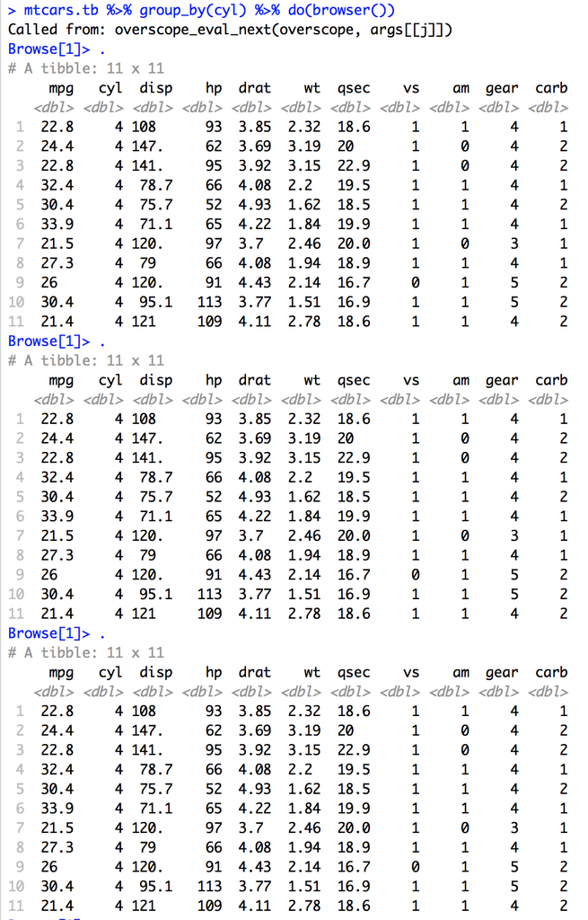

```r
mtcars.tb %>%
  group_by(cyl) %>%
  do(browser())
```

接著，如果我們想要看分組後的資料總結，可以使用 `summarise` 函數：

```r
mtcars.tb %>%
  group_by(cyl) %>%
  summarise(
    number = n(),
    avg_hp = mean(hp),
    sd_hp = sd(hp),
    max_hp = max(hp),
    min_hp = min(hp)
  ) %>%
  arrange(desc(avg_hp))
```

```
## # A tibble: 3 x 6
##     cyl number avg_hp sd_hp max_hp min_hp
##   <dbl>  <int>  <dbl> <dbl>  <dbl>  <dbl>
## 1     8     14  209.   51.0    335    150
## 2     6      7  122.   24.3    175    105
## 3     4     11   82.6  20.9    113     52
```

```r
mtcars.tb %>%
  group_by(cyl) %>%
  filter(rank(desc(hp)) < 4) %>%
  arrange(desc(cyl), desc(hp))
```

```
## # A tibble: 10 x 11
## # Groups:   cyl [3]
##      mpg   cyl  disp    hp  drat    wt  qsec    vs    am  gear  carb
##    <dbl> <dbl> <dbl> <dbl> <dbl> <dbl> <dbl> <dbl> <dbl> <dbl> <dbl>
##  1  15       8 301     335  3.54  3.57  14.6     0     1     5     8
##  2  15.8     8 351     264  4.22  3.17  14.5     0     1     5     4
##  3  14.3     8 360     245  3.21  3.57  15.8     0     0     3     4
##  4  13.3     8 350     245  3.73  3.84  15.4     0     0     3     4
##  5  19.7     6 145     175  3.62  2.77  15.5     0     1     5     6
##  6  19.2     6 168.    123  3.92  3.44  18.3     1     0     4     4
##  7  17.8     6 168.    123  3.92  3.44  18.9     1     0     4     4
##  8  30.4     4  95.1   113  3.77  1.51  16.9     1     1     5     2
##  9  21.4     4 121     109  4.11  2.78  18.6     1     1     4     2
## 10  21.5     4 120.     97  3.7   2.46  20.0     1     0     3     1
```